# p8105_hw1_xz3078

Xinyi Zhou

# Problem 1

```r
x = rnorm(10)
df = tibble(
  vec_numeric = x,
  vec_logical = x > 0,
  vec_char = c("One", "Two", "Three", "Four", "Five", "Six", "Seven", "Eight", "Nine", "Ten"),
  vec_factor = factor(c("Group1", "Group1", "Group3", "Group2", "Group1", "Group3", "Group2", "Group2", "Group3", "Group2"))
)
df
```

```
## # A tibble: 10 x 4
##    vec_numeric vec_logical vec_char vec_factor
##          <dbl> <lgl>       <chr>    <fct>
##  1      0.403  TRUE        One      Group1
##  2     -0.263  FALSE       Two      Group1
##  3      0.465  TRUE        Three    Group3
##  4      0.659  TRUE        Four     Group2
##  5      0.928  TRUE        Five     Group1
##  6      0.329  TRUE        Six      Group3
##  7      2.33   TRUE        Seven    Group2
##  8      1.74   TRUE        Eight    Group2
##  9     -0.0589 FALSE       Nine     Group3
## 10     -0.956  FALSE       Ten      Group2
```

```r
num = pull(df, vec_numeric)
mean(num)
```

```
## [1] 0.5576115
```

```r
logical = pull(df, vec_logical)
mean(logical)
```

```
## [1] 0.7
```

```r
char = pull(df, vec_char)
mean(char)
```

```
## [1] NA
```

```r
fac = pull(df, vec_factor)
mean(fac)
```

```
## [1] NA
```

The mean works for numeric variables and logical variables, but doesn’t work for character variables or factor variables.

```r
as.numeric(logical)
as.numeric(char)
as.numeric(fac)
```

[output not shown]

Logical variables can be converted into 0 and 1 because logical variables contain values of either TRUE or FALSE. 3-level factor variable can be converted into 1, 2, and 3 because factor variables separate unique values into levels. Therefore, factor variables can be converted into numeric variables based on levels. However, character variables cannot be converted into numeric variables because character variables are sets of text strings. We can only take the mean of numeric or logical variables. Although factor variables can be converted into numeric variables, we cannot directly take the mean of a factor variable.

# Problem 2

```r
data("penguins", package = "palmerpenguins")
```

In the penguins dataset, the variable names are species, island, bill_length_mm, bill_depth_mm, flipper_length_mm, body_mass_g, sex, year. There are 3 levels under factor species, which are Adelie, Chinstrap, Gentoo. There are 3 levels under factor island, which are Biscoe, Dream, Torgersen. The year are 2007, 2008, 2009. The dataset has 344 rows and 8 columns. The mean flipper length is 200.9152047mm.

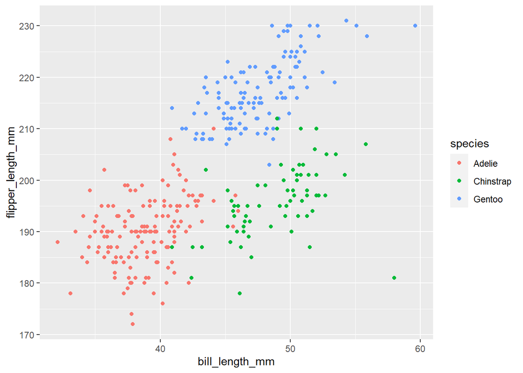

```r
ggplot(penguins, aes(x = bill_length_mm, y = flipper_length_mm, color = species)) + geom_point()
```

```r
ggsave("scatter_plot.pdf", height = 4, width = 6)
```